# Somewhat more advanced plotting in base `R`: Plotting confidence bands with transparency (and other tricks)

Ian Dworkin

# 1 The anatomy of a more advanced plot.

## 1.1 Introduction

Both base *R* and *ggplot2* have amazing plotting capabilities. It is worth going “deep” with one or the other. Thankfully there are many online galleries of R plots, with code. [Here](https://www.r-graph-gallery.com/) is a nice general gallery of plots with code for both base *R* and *ggplot2*. [Here](http://www.ggplot2-exts.org/gallery/) are some *ggplot2* specific plots (with the extensions).

Here is just some examples of making nicer and more useful plots all in base R. Most of this can be easily accomplished in `ggplot2` (often pretty easily). However, I often find there are times when it is easier to make the exact modifications using base plots.

Also note (if you are running this in R studio) I highly recommend making high quality figures by generating PDF graphic devices. The ones that are outputted for markdown documents or html are not super high quality. See `?pdf` for this but you basically just need to call `pdf(file = YourFileName.pdf)` before you generate the plot and `dev.off()` after the plot. I am not showing that here.

## 1.2 A basic regression with confidence bands

### 1.2.1 Simulate some data and fit a linear model (simple linear regression)

```r
x <- 1:50
y <- rnorm(n = length(x), mean = (2 + (0.8*x)), sd= 4)
model_1 <- lm(y ~ x)
```

Now we generate a sequence of “x” values for which to estimate y values (both fitted and CI’s). This can be a sequence spanning the range of the data or, the actual data sorted from lowest to highest (see later example).

```r
new <- data.frame(x = seq(min(x), max(x), 1))
```

Now we predict the new data using the estimates from `model_1`. using `interval = confidence` in `pred()` will give fitted values +95%CI on estimates. These are different from the prediction intervals (which can also be called).

```r
pred <- predict(model_1, newdata = new, interval = "confidence")
```

## 1.3 Now we can plot!

We will start by plotting the confidence bands around the estimated best fit line with (graphically) simple confidence bands with additional lines representing the upper and lower 95% CIs on the predicted values.

We could do this line by line:

```r
plot(y ~ x, pch = 20, cex = 1.5)
lines(x = new[,1], y = pred[,1], lwd = 3) # this would be the same as abline(model.1)
```

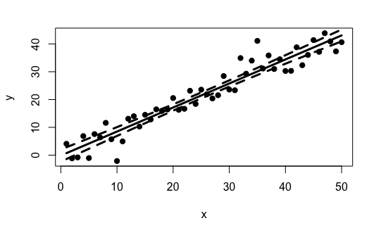

```r
lines(x = new[,1], y = pred[,3], lwd = 3, lty = 2)
lines(x = new[,1], y = pred[,2], lwd = 3, lty = 2)
```

However I prefer using the `matlines()` to do this.

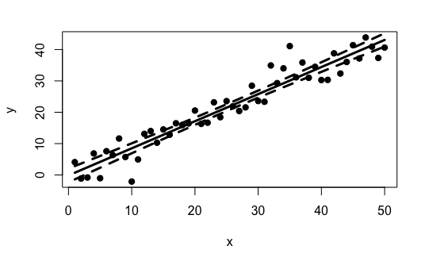

```r
plot(y ~ x, pch = 20, cex = 1.5)
matlines(x = new[,1], y = pred[,1:3], lwd=c(3,3,3), lty=c(1,2,2), col = 1)
```

### 1.3.1 Plotting the confidence band as a shaded region.

Some prefer plotting this as shaded region. There are a few steps. First plotting an empty plot window (using `type = 'n'` in `plot()`). Then we will draw a polygon to define the shaded region, finally, we will add the observed data points back onto the plot.

We are going to make an arbitrary polygon where we stitch together the x values going forward and reverse, as well as lower CI and upper CI (I make upper go in reverse, but it is an arbitrary choice)

```r
plot(y ~ x, pch= 20, type = "n")
polygon(x = c(1:nrow(new), nrow(new):1),
    y = c(pred[,2], rev(pred[,3])),
    col="grey", border = "grey")
```

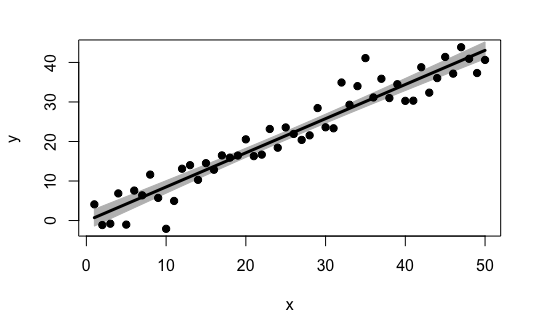

```r
lines(x = new[,1], y = pred[,1], lwd = 3)
# And the data
points(y ~ x, pch = 20, cex = 1.5)
```